# DSC 011 Sp25 Lab 13 v3: R/tidyverse Pipelines for Statistical Analysis of Baby Names Data

Featuring Universal Hashchecks for Immediate Feedback

Author

Caleb Koenig

Published

May 9, 2025

## 1 Introduction

This is the Quarto template notebook for Lab 13 in the first Spring 2025 offering of DSC 011: Computing and Statistical Programming at UC Merced, with a focus on computing, visualizing, modeling and communicating interval estimates for sample proportions and means in R/tidyverse, and computing data science workflows with mixed R/tidyverse pipelines.

The text contains brief but self-contained introductions to statistics of interval estimation for proportions and means, some background on the Sex Ratio at Birth statistic, the importance and ethics of uncertainty estimation in data science communication, examples of using $\LaTeX$ to write equations in markdown (which works in Quarto, RMarkdown, and Jupyter notebooks), a little on how to choose among different implementation strategies when computing data science workflows in the R/tidyverse. Finally, research on rank aggregation methods is presented and applied to create aggregate summaries of U.S. baby names over decades.

This file is distributed through git by pulling from the original DSC-011-Sp25-Baby-Names private template upstream repository, and appears at the top-level of the repository.

The content of this template Quarto file is Copyright (2025) David H. Ardell.

## 2 Assignment

### 2.1 First Steps

1. If you haven’t already, inside your cloned project directory, pull the new notebook file and changes by executing in Bash:

   ```
   git pull git@github.com:dhard/DSC-011-Sp25-Baby-Names.git
   ```

2. After pulling changes, restore your `renv` environment and install R dependencies for the project:

   In your Bash/Zsh shell, change directory into the top-level `DSC-011-Sp25-Baby-Names` project directory, and execute the bash command:

   ```
   R -e "renv::restore()"
   ```

3. Then in RStudio, you can open the R project associated with the top-level `DSC-011-Sp25-Baby-Names` project directory.
4. Open this Quarto notebook file (with `.qmd` extension) in RStudio.
5. Select menu item File -> Rename and rename the file to contain your first initial and last name.
6. Update the Author information in the YAML header at the top of the file.
7. Save the file.

**Caution**

Make sure to save your renamed file in the top-level of the project directory, in the same place as the original notebook template file called `DSC-011-Sp25-Lab12_FirstInitial_LastName.qmd` or else the quarto interpreter and its child R interpreter may not be able to find all of the file dependencies of this notebook when you try to render it.

8. Render the notebook. If you get errors, make sure that the notebook file is at the top-level of the project directory.

**Render Quarto Notebooks in Bash**

You can also render a Quarto notebook to HTML in your Bash/Zsh terminal by executing a command such as:

```
quarto render DSC-011-Sp25-Lab13_FirstInitial_LastName.qmd
```

### 2.2 Load Package Dependencies of this Notebook

Here at the top of the notebook we load all the packages required to run its code. This is the first code chunk, so it will be the first one to run in the **freshly-spawned child R interpreter of the Quarto interpreter** when you Render.

However, while working this assignment interactively in RStudio, you will need to get your **Session R Interpreter,** the one running in your RConsole as a child of your current RStudio session, to behave like the one that renders the notebook.

So run the following code chunk by (press the green “play” triangle button at the top of its right side):

```r
library(tidyverse)
library(babynames)
library(binom)
library(ggokabeito)
library(TopKLists)
```

### 2.3 Load Object Definitions and Data from our Project Directory

#### 2.3.1 Load Object Definitions from Lab 12 (#sec-load)

9. Try to load the data and object definitions by playing the following code chunk

```r
source("scripts/03-explore.R")
```

```
> baby_clean <- read.csv("data/clean/baby_clean.csv",
+     header = T)

> baby_clean_f <- read.csv("data/clean/baby_clean.csv",
+     header = T, stringsAsFactors = T)

> baby_letters <- read.table("data/clean/baby_letters.txt",
+     header = T)

> babies_born_by_decade_and_sex <- as.data.frame(do.call(rbind,
+     lapply(split(baby_clean_f, baby_clean_f$decade), function(x) {
+         apply( .... [TRUNCATED]

> babies_born_by_name_and_sex <- as.data.frame.matrix(do.call(rbind,
+     c(lapply(sort(unique(baby_clean$boy_name)), function(x) {
+         c(x, " ..." ... [TRUNCATED]

> names(babies_born_by_name_and_sex) <- c("name", "sex",
+     "freq")

> dim(babies_born_by_name_and_sex)[1]
[1] 1236

> sex_ratio_by_decade <- babies_born_by_decade_and_sex$boy_freq/apply(babies_born_by_decade_and_sex,
+     1, sum)

> mean_rank_by_name_and_sex <- as.data.frame.matrix(do.call(rbind,
+     c(lapply(sort(unique(baby_clean$boy_name)), function(x) {
+         c(x, "bo ..." ... [TRUNCATED]

> names(mean_rank_by_name_and_sex) <- c("name", "sex",
+     "mean_rank")

> mean_rank_by_name_and_sex$mean_rank <- as.numeric(mean_rank_by_name_and_sex$mean_rank)

> babies_born_by_name_and_sex$freq <- as.numeric(babies_born_by_name_and_sex$freq)

> baby_letters_rel <- cbind(baby_letters[, 1], sweep(baby_letters[,
+     -1], 2, apply(baby_letters[, -1], 2, sum), FUN = "/"))

```

[output cut: 22 more lines]

```
Test 3:
Is the variable "babies_born_by_decade_and_sex" defined? YES.
Testing the value of babies_born_by_decade_and_sex: CORRECT
Test 4:
Is the variable "babies_born_by_name_and_sex" defined? YES.
Testing the value of babies_born_by_name_and_sex: CORRECT
Test 5:
Is the variable "sex_ratio_by_decade" defined? YES.
Testing the value of sex_ratio_by_decade: CORRECT
Test 6:
Is the variable "mean_rank_by_name_and_sex" defined? YES.
Testing the value of mean_rank_by_name_and_sex: CORRECT
Test 7:
Is the variable "baby_letters_rel" defined? YES.
Testing the value of baby_letters_rel: CORRECT
```

1. If the sourced script runs and you get all Tests CORRECT, you can move on to the next step.
2. If the sourced script runs and you don’t get all Tests CORRECT, then you need to complete Lab 11 and make changes to the definitions and code in file `scripts/03b-compute-summaries.R`.
3. If the sourced script doesn’t run, make sure this notebook file is located at the top-level of the project directory, so that you saved your renamed file in the same place as the original file called `DSC-011-Sp25-Lab13_FirstInitial_LastName.qmd`.

#### 2.3.2 Load Data

10. Play the following code chunk to load the baby names and baby letters data as tibbles.

```r
baby_clean_tib <- read_csv("data/clean/baby_clean.csv", ## read_csv is from tidyverse readr and makes tibbles
                       show_col_types = FALSE)
baby_letters_tib <- read_table("data/clean/baby_letters.txt",
                       show_col_types = FALSE)

# Make baby_clean_tidy
baby_clean_tidy <- baby_clean_tib |> pivot_longer(cols=boy_name:girl_freq,names_sep = "_",names_to = c("sex",".value"))
digest::digest(baby_clean_tidy) == "430495299e0fd864ebed0d63c65212f6"
```

```
[1] TRUE
```

There should be one output of TRUE if all is well-defined for this assignment.

### 2.4 Interval Estimates for Sex Ratio in Baby Names Data by Decade

#### 2.4.1 Top-200 Baby Names Data

##### 2.4.1.1 Computing Credible Intervals for Sex Ratio by Decade

###### 2.4.1.1.1 A Little Background on Sex Ratio at Birth

We previously computed the Sex Ratio at Birth (SRB) from the baby names data. The following code chunk prints its values on Render as a reminder:

```r
sex_ratio_by_decade
```

```
    1880s     1890s     1900s     1910s     1920s     1930s     1940s     1950s
0.4594740 0.3469095 0.3244410 0.4572775 0.4904915 0.5130107 0.5264436 0.5378342
    1960s     1970s     1980s     1990s     2000s     2010s
0.5480919 0.5636521 0.5656493 0.5706307 0.5849298 0.5783947
```

A more complete and self-descriptive name for this summary vector would have been `proportion_boy_births_by_decade`. But the name `sex_ratio_by_decade` is apt.

In demography and statistics on human births, the SRB $\hat{p}_t$ in decade $t$ is conventionally defined as the number ($b_t$) of boy babies born in that decade among a sample ($n_t=b_t+g_t$) of births in that decade (among those babies for whom sex has been unambiguously defined at birth), where $g_t$ is the number of girl babies born in decade $t$.

$$\hat{p_t} = \frac{b_t}{b_t+g_t}$$

###### 2.4.1.1.2 The Importance of Interval Estimates in General

We symbolize the SRB here in decade $t$ by $\hat{p}_t$ to emphasize that it is a **sample proportion**, **rate** or **relative frequency**. The “hat” means that $\hat{p}_t$ is an **estimate** of an unknown population parameter, here a proportion or rate, assumed to be either **independent and identically distributed** or, more generally, **exchangeable** over the sample.

As shown at the top of [Chapter 2 on Statistical Modeling](https://www.huber.embl.de/msmb/02-chap.html) in Holmes and Huber (2019), sample estimators of unknown population parameters are often symbolized with roman letters and hats, while their corresponding parameters are often symbolized by their greek letter homologous equivalents. Alternatively, greek letters are avoided entirely and estimates are symbolized by adding hats to roman letters symbolizing the population-level parameters. For example, unknown population proportions or rates are usually symbolized as either $\pi$ or $p$. The symbology makes clear that a population-level proprtion or rate is a **probability in the frequentist sense.** For more information on alternative definitions of probability and a fun self-quiz you can take to find out where you fall on the Bayesian-frequentist probability spectrum in your thinking, please see [“Chapter 1 The Big (Bayesian) Picture”](https://www.bayesrulesbook.com/chapter-1) in Johnson, Ott, and Dogucu (2022).

In previous work in DSC 011, we have only computed **point estimates** of the sample proportion of boy births by decade, but this is not sufficient for real data scientific work. This is because in general, when possible, we should always report **interval estimates** in addition to point estimates in our data scientific reports. This is a foundational criterion of ethical and reproducible data science and science in general.

In any scientific context we are obligated to report the **uncertainties** of our estimates, which, among other things, depend on sample sizes ($n$) through **The Square Root Law:** that is, uncertainty is inversely proportional to the square root of sample size $n$. Put another way, you must sample four times as much data to cut the uncertainty (and width of an interval estimate) in half.

###### 2.4.1.1.3 Interval Estimates for Proportions

The **Central Limit Theorem (CLT)** tells us that when sample size $n$ becomes large enough, a sample mean ($\bar{x}$) is a normally distributed random variable that is a superior point estimate $\mu$ and standard deviations (equal to the **Standard Errors of the Mean**), even when the underlying data that we computed a sample mean from are not themselves normally distributed. But the CLT does not tell us how large samples sizes have to be in order to achieve some specified level of certainty in our estimates.

Sample proportions are sample means. They are random sums of $n > 1$ **indicator or Bernoulli random variables** that take the value 1 when an event of a certain category occurs and a value 0 when events of other categories occur.

**Note**

**One-Hot Encoding** uses as many indicator or Bernoulli random variables as there are factor levels in a categorical variable to achieve binary encoding of **categorical random variables**.

It turns out that **Bayesian credible intervals** are generally more accurate and the recommended interval estimates of sample proportions than **frequentist confidence intervals** based on the CLT, particularly when any of these conditions hold: the underlying parameter $\pi$ is close in value to 0 or 1, sample size is limited, or there exists prior knowledge about the proportion being estimated.

For the sex ratio data, $\pi \approx 0.5$ and sample sizes are large. In this case, the Bayesian credible intervals using a **“flat” (or Standard Uniform) prior distribution for $\pi$** are expected to converge to the same upper and lower bounds as frequentist confidence intervals.

For your future reference, this section used $\LaTeX$-styled equations in Quarto markdown. $\LaTeX$ equations are the standard way to write equations in RMarkdown and Quarto.

###### 2.4.1.1.4 Computing Point and Interval Estimates for Proportions in R

In order to compute interval estimates for proportions, we need access to the raw data, the absolute frequencies of boy and girl births per decade. For the kind of math we need to do, it’s easier to compute the point and interval estimate statistics directly in base-R using vectorized aritmetic on the data-frame column vectors, particularly using the untidy summary that we originally computed using `split()` in Lab 10, where the boy and girl birth frequencies are aligned in rows by decade.

Let’s print this original data summary data-frame out to remind us what it looks like.

@ Play the following code chunk and also render the notebook and read it as you continue to work in RStudio.

```r
babies_born_by_decade_and_sex
```

```
      boy_freq girl_freq
1880s   961549   1131168
1890s   983401   1851347
1900s  1142330   2378588
1910s  5474625   6497591
1920s  9104126   9457105
1930s  8905213   8453513
1940s 12920834  11622790
1950s 17597599  15121775
1960s 16341889  13474077
1970s 13333773  10322259
1980s 14657537  11255229
1990s 14146775  10644698
2000s 12979118   9210073
2010s 10905209   7949058
```

In order to compute/recompute both the point and interval estimates of the proportions of the Sex Ratio at Birth, let’s start by adding a column of marginal totals to this data-frame. Vector arithmetic is generally length-preserving, so naturally creates new columns we can add back to our input data-frame to accumulate row-wise statistical summaries.

Because we can represent the computations in this section that we need in simple arithmetic terms with the variable names, and — critically, we are not using information that depends on complex ways across multiple columns — we can use vectorized arithmetic with the existing data-frame columns to create new named columns using assignment operator (`<-`), instead of using the `apply()` approach that we used previously. Vectorized arithmetic is nice when can you can use it. It is more readable. tidyverse offers the verb `mutate()` for the purpose also taking advantage of vectorized arithmetic to add columns to tibbles. However, here since our input is a bae-R data-frame. Let’s practice our base-R skills in this section.

**Note**

As Moore and Mertens (2011) describe, the pioneers of computability Alonzo Church and Alan Turing, and others proved that a machine needs functions like `apply()` or `while()` loops in addition to `for()` loops to effect the most general and universal class of computable functions and achieve Turing-completeness. The availability of functions `apply()`, `lapply()` and friends in R affords us with a wider range of computation than can vectorized arithmetic alone.

11. Down in the R Console, write a base-R expression like `babies_born_by_decade_and_sex$total <-` to compute the total number of babies born by decade in a new column in the `babies_born_by_decade_and_sex` data-frame with the name “total” using vectorized arithmetic with the existing column vectors of this data-frame (not `apply()`). If you have problems and need to regenerate the original value of `babies_born_by_decade_and_sex` (start over), all that you need to do is re-run the code chunk above that generates this object by sourcing the R script `03-explore.R`. You can also remove a column in a data-frame by assigning it the value `NULL` in the R Console.
12. Once you believe you have correctly solved the problem, play the following code chunk labelled “test_babies_born_by_decade_and_sex_1” by pressing its “play” button. If it returns FALSE, keep working on your definition of `babies_born_by_decade_and_sex` in the R Console, and use your command-line history to validate your solution until it returns TRUE. If you have problems and need to regenerate the original value of `babies_born_by_decade_and_sex` (start over), all that you need to do is re-run the code chunk above that generates this object by sourcing the R script `03-explore.R`. You can also remove a column in a data-frame by assigning it the value `NULL`.

```r
digest::digest(babies_born_by_decade_and_sex |>
                 mutate(across(where(is_double),round,digits=7))) == "ccfc7e473c055cf76d10ee82596ba579"
```

13. Once you have validated your solution, copy your code that modifies `babies_born_by_decade_and_sex` correctly here in code chunk labeled “define-babies_born_by_decade_and_sex”.

```r
babies_born_by_decade_and_sex$total <- babies_born_by_decade_and_sex$boy_freq + babies_born_by_decade_and_sex$girl_freq
```

Now let’s use our data in the “total” column to recalculate the point estimates of the sample proportion by decade and include them back as a new column in this source data-frame. This will make it easier to graph the point estimates together with the interval estimates.

14. Down in the R Console, write a base-R expression like `babies_born_by_decade_and_sex$sex_ratio <-` to recompute the sample sex ratios by decade in a new column in the `babies_born_by_decade_and_sex` data-frame with the name “sex_ratio” using vectorized arithmetic and the existing columns of this data-frame. If you have problems and need to regenerate the original value of `babies_born_by_decade_and_sex` (start over), all that you need to do is re-run the code chunk above that generates this object by sourcing the R script `03-explore.R`. You can also remove a column in a data-frame by assigning it the value `NULL`.
15. Once you believe you have correctly solved the problem, play the following code chunk labelled “test_babies_born_by_decade_and_sex_2” by pressing its “play” button. If it returns FALSE, keep working on your definition of `babies_born_by_decade_and_sex` in the R Console, and use your command-line history to validate your solution until it returns TRUE. If you have problems and need to regenerate the original value of `babies_born_by_decade_and_sex` (start over), all that you need to do is re-run the code chunk above that generates this object by sourcing the R script `03-explore.R`. You can also remove a column in a data-frame by assigning it the value `NULL`.

```r
digest::digest(babies_born_by_decade_and_sex |>
              mutate(sex_ratio=round(sex_ratio,digits=7))) ==
  "a06e855118aab35b86a9b9384bc5e42c"
```

16. Once you have validated your solution, copy your code that modifies `babies_born_by_decade_and_sex` correctly here in code chunk labeled “define-babies_born_by_decade_and_sex_2”.

```r
babies_born_by_decade_and_sex$sex_ratio <- babies_born_by_decade_and_sex$boy_freq / babies_born_by_decade_and_sex$total
```

17. Now let’s compute interval estimates. Down in the R Console, in order to compute 99% Bayesian credible intervals assuming a flat prior distribution, use the `binom.confint()` function from the `binom` package. Use as its first argument `x` the vector of boy births, as its second argument `n` the vector of total births, provide as a third optional argument `conf.level = 0.99`, specify `method=bayes` and specify a flat prior by providing fourth and fifth arguments `prior.shape1 = 1.0` and `prior.shape2 = 1.0`. Finally, avoid warnings about convergence of intervals using a sixth optional argument `tol=1e-11` Save the result in an R object called `SRB_bayes_CI`.
18. When you believe you got it right, copy your assignment expression in the code chunk here below to test its value.

```r
SRB_bayes_CI <- binom.confint(babies_born_by_decade_and_sex$boy_freq, babies_born_by_decade_and_sex$total, conf.level = 0.99, methods = "bayes", prior.shape1 = 1.0, prior.shape2 = 1.0, tol = 1e-11)
try(digest::digest(SRB_bayes_CI |>
               mutate(across(where(is_double),round,digits=7))) ==  "a317eaf3af054446d050f2d91c9712f0")
```

[output not shown]

```
[1] TRUE
```

19. Now, down in the R console, use assignment to copy the columns `SRB_bayes_CI$lower` and `SRB_bayes_CI$upper` to the `babies_born_by_decade_and_sex` data-frame with the same names. Check the result to make sure it is correct. Then copy your two assignment expressions into the code chunk below to test the value of `babies_born_by_decade_and_sex`

```r
babies_born_by_decade_and_sex$lower <- SRB_bayes_CI$lower
babies_born_by_decade_and_sex$upper <- SRB_bayes_CI$upper
try(digest::digest(babies_born_by_decade_and_sex |>
               mutate(across(where(is_double),round,digits=7))) ==
              "104d2f2ae7d100baf04531ea57bb011d")
```

```
[1] TRUE
```

20. Finally, down in the R console, to make graphing easy in ggplot2, let’s create a new decade column in `babies_born_by_decade_and_sex` called “decade” and assign it values for the decades from 1880 to 2010 using the `seq()` function with its `by=` option. After you have gotten it rightly defined, copy

```r
babies_born_by_decade_and_sex$decade <- seq(1880, 2010, by = 10)
try(digest::digest(babies_born_by_decade_and_sex |>
                    mutate(across(where(is_double),round,digits=7))) ==
   "24f200e7dc3364fbd3224c9188edad60")
```

```
[1] TRUE
```

##### 2.4.1.2 Visualizing Credible Intervals for Sex Ratio Data

Now we are ready to graph the interval estimates of sex ratio by decade.

21. Down in the R Console, use the `as_tibble()` function on `babies_born_by_decade_and_sex` and pipe it to a graph expression that has these characteristics:
1. Use `aes()` in the call to `ggplot()` to associate the aesthetics x with decade, y with sex_ratio.
2. Use `geom_errorbar()` with an additional call to `aes()` to associate the aesthetic ymin with the name “lower” and ymax with the name “upper”.
3. Make the point estimates easier to see by extending the graph expression with calls to `geom_point()` and `geom_line()`
4. Extend the graph expression with `ylim()` to set the y-axis limits to the values 0 and 1.
5. Extend the graph expression with `geom_hline(yintercept=0.5)` to draw a reference line for an even sex ratio of 0.5.
6. Extend the graph expression to add meaningful labels of “Decade” for the x-axis, “Sex Ratio at Birth (SRB)” for the y-axis, “Sex Ratio at Birth By Decade in Top-200 Baby Names Data” as a title, “Bayesian Credible Intervals Shown Assuming a Flat Prior Distribution” as a subtitle, and “Data from U.S. Social Security Administration obtained April, 2025” as the caption.
22. After you have perfected your graph expression in the Console, please copy it here to include the graph in your notebook:

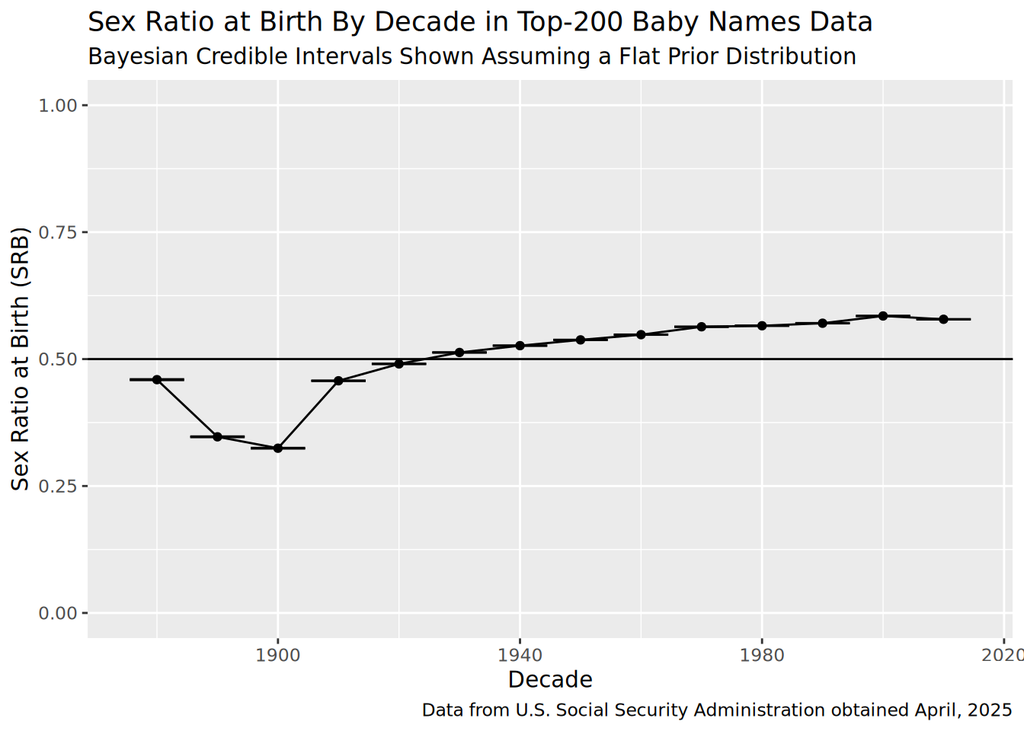

```r
as_tibble(babies_born_by_decade_and_sex) |>
  ggplot(aes(x = decade, y = sex_ratio)) +
  geom_errorbar(aes(ymin = lower, ymax = upper)) +
  geom_point() +
  geom_line() +
  ylim(0, 1) +
  geom_hline(yintercept = 0.5) +
  labs(x = "Decade", y = "Sex Ratio at Birth (SRB)", title = "Sex Ratio at Birth By Decade in Top-200 Baby Names Data", subtitle = "Bayesian Credible Intervals Shown Assuming a Flat Prior Distribution", caption = "Data from U.S. Social Security Administration obtained April, 2025")
```

Our graph appears to show a strong rejection of the prior hypothesis of an even sex ratio ($H_0:\pi = 0.5$). But how much of the fluctuation in sex ratio by decade is from limited sampling of births? What is the true value of the SRB in humans?

#### 2.4.2 Full Baby-Names Data by Year from 1880-2017

Hadley Wickham, the principal author of ggplot2 and the tidyverse, provides the R package `babynames` which contains a much larger and more granular version of the baby-names data that we have been analyzing. Besides that the `babynames` data it provides is already in a tidy tibble, two other important differences, between the top-200 rank data that we curated and the `babynames`-package provided tibble data, are that the latter is summarized by year instead of decade, and that it is much more complete, and includes all names with a frequency of at least 5 births per year.

To see how much bigger the full babynames data is, inspect the output of the following code chunk:

```r
library(babynames)
cat("## Top-200 Baby Names:\n")
```

```
## Top-200 Baby Names:
```

```r
glimpse(baby_clean_tidy)
```

```
Rows: 5,600
Columns: 5
$ decade <dbl> 1880, 1880, 1880, 1880, 1880, 1880, 1880, 1880, 1880, 1880, 188…
$ rank   <dbl> 1, 1, 2, 2, 3, 3, 4, 4, 5, 5, 6, 6, 7, 7, 8, 8, 9, 9, 10, 10, 1…
$ sex    <chr> "boy", "girl", "boy", "girl", "boy", "girl", "boy", "girl", "bo…
$ name   <chr> "John", "Mary", "William", "Anna", "James", "Emma", "George", "…
$ freq   <dbl> 89949, 91668, 84881, 38159, 54056, 25404, 47651, 25006, 46656, …
```

```r
cat("\n## Full Baby Name Dataset:\n")
```

```
## Full Baby Name Dataset:
```

```r
glimpse(babynames)
```

```
Rows: 1,924,665
Columns: 5
$ year <dbl> 1880, 1880, 1880, 1880, 1880, 1880, 1880, 1880, 1880, 1880, 1880,…
$ sex  <chr> "F", "F", "F", "F", "F", "F", "F", "F", "F", "F", "F", "F", "F", …
$ name <chr> "Mary", "Anna", "Emma", "Elizabeth", "Minnie", "Margaret", "Ida",…
$ n    <int> 7065, 2604, 2003, 1939, 1746, 1578, 1472, 1414, 1320, 1288, 1258,…
$ prop <dbl> 0.07238359, 0.02667896, 0.02052149, 0.01986579, 0.01788843, 0.016…
```

##### 2.4.2.1 Adding Reference for Full Baby-Names Dataset

23. Execute `citation("babynames")` in the R Console to obtain a BibTeX record to cite when using the babynames package.
24. In RStudio, open the file “DSC-011-Sp25-Lab13.bib” and paste this record into it. Edit the first line of the record to give it a unique key so you can cite this reference in your Quarto notebook. Add a key to be able to cite the record, by changing the text from `@Manual{,` to read `@Manual{wickham21,`.

##### 2.4.2.2 Using Tidyverse Pipelines to Aggregate Full Dataset byDecade and Sex, Pivot and Compute Point Estimates

In this exercise, since we are using a tidyverse tibble, we will practice using the tidyverse to compute summary statistics.

25. Down in the R Console, develop a tidyverse pipeline to compute sex ratio estimates for the Full Babynames Dataset.
1. To compute the decade for each row in `babynames`, pipe it through the tidyverse verb `mutate(decade=year %/% 10 * 10)`, which adds the decade column and uses modular integer arithmetic to compute the decade from the year.
2. Use up-arrow command-line editing to extend your tidyverse pipeline to prepare to summarize the data by decade and sex, by piping its output through `group_by(decade, sex)` and then extend it further by piping to the tidyverse function `summarize(freq-sum(n))` to make a new data-frame with the sum of the `babynames$n` column aggregated by decade and sex. Examine the output.
3. Use up-arrow command-line editing to extend your tidyverse pipeline to use the `pivot_wider()` function with arguments `names_from = sex` and `values_from = freq` to reshape the tibble to be similar in dimensions to `babies_born_by_decade_and_sex`.
4. Use up-arrow command-line editing to extend your tidyverse pipeline to use the tidyverse function `mutate()` to add a column called `total` to this tibble containing the sum of the “M” and “F” columns.
5. Use up-arrow command-line editing to extend your tidyverse pipeline with another call to `mutate()` to add a column called `sex_ratio` to the tibble and assign the return value to a tibble with the name `babies_born_by_decade_and_sex_full`.
26. Once you have correctly completed all the previous steps, copy your assignment tidyverse pipeline to the following code chunk to test its value. Tidyverse will issue a warning “summarise()` has grouped output by ‘decade’.” that you are free to ignore.

```r
babies_born_by_decade_and_sex_full <- babynames |>
  mutate(decade = year %/% 10 * 10) |>
  group_by(decade, sex) |>
  summarize(freq = sum(n), .groups = "drop_last") |>
  pivot_wider(names_from = sex, values_from = freq) |>
  mutate(total = F + M) |>
  mutate(sex_ratio = M / total)
try(digest::digest(babies_born_by_decade_and_sex_full |>
                 mutate(across(where(is_double),round,digits=7))) ==
  "d0669f30ec421cfd8fc600be22f89719")
```

```
[1] TRUE
```

##### 2.4.2.3 Compute and Aggregate Interval Estimates for Sex Ratio at Birth in Full Data Set

27. Down in the R Console, adapt your existing code from the code chunk above that defined the R object `SRB_bayes_CI` to compute lower and upper bounds of the same type of 99% credible interval estimates with a flat prior distribution that we used previously for the top-200 rank dataset, but now apply it to the full data-set summary in `babies_born_by_decade_and_sex_full`. Use optional argument `tol=1e-13` to help all the intervals converge, and assign it to the new R object `SRB_bayes_CI_full`.
28. When you believe you got it right, copy your assignment expression in the code chunk here below to test its value.

```r
SRB_bayes_CI_full <- binom.confint(babies_born_by_decade_and_sex_full$M, babies_born_by_decade_and_sex_full$total, conf.level = 0.99, methods = "bayes", prior.shape1 = 1.0, prior.shape2 = 1.0, tol = 1e-13)
try(digest::digest(SRB_bayes_CI_full |>
                 mutate(across(where(is_double),round,digits=7))) ==  "995bc71b7f9bb806da1979606f2a8399")
```

```
[1] TRUE
```

29. Now, down in the R console, use base-R assignment to copy the `SRB_bayes_CI_full$lower` and `SRB_bayes_CI_full$upper` columns to new columns `lower` and `upper` respectively in `babies_born_by_decade_and_sex_full`. Once you succeed, copy the assignments into the code chunk below and run it to test the value.

```r
babies_born_by_decade_and_sex_full$lower <- SRB_bayes_CI_full$lower
babies_born_by_decade_and_sex_full$upper <- SRB_bayes_CI_full$upper
try(digest::digest(babies_born_by_decade_and_sex_full |>
                 mutate(across(where(is_double),round,digits=7))) ==
   "65feee9130b7da359193ff2ecff9f9d6")
```

```
[1] TRUE
```

##### 2.4.2.4 Visualizing Sex-Ratio Statistics by Decade in the Full Baby Names Data Set

30. Down in the R Console, pipe the `babies_born_by_decade_and_sex_full` tibble into a graph expression that has the following characteristics, using a copy of your previous graph expression as a starting point:
1. Use `aes()` in the call to `ggplot()` to associate the aesthetics x with decade, y with sex_ratio.
2. Use `geom_errorbar()` with an additional call to `aes()` to associate the aesthetic ymin with the name “lower” and ymax with the name “upper”.
3. Make the point estimates easier to see by extending the graph expression with calls to `geom_point()` and `geom_line()`
4. Extend the graph expression with `ylim()` to set the y-axis limits to the values 0 and 1.
5. Extend the graph expression with `geom_hline(yintercept=0.5)` to draw a reference line for an even sex ratio of 0.5.
6. Extend the graph expression to add meaningful labels of “Decade” for the x-axis, “Sex Ratio at Birth (SRB)” for the y-axis, “Sex Ratio at Birth in Full Baby Names Data Aggregated by Decade” as a title, “Bayesian Credible Intervals Shown Assuming a Flat Prior Distribution” as a subtitle, and `“Data from the R babynames package version 1.0.1” as the caption.
31. After you have perfected your graph expression in the Console, please copy it here to include the graph in your notebook:

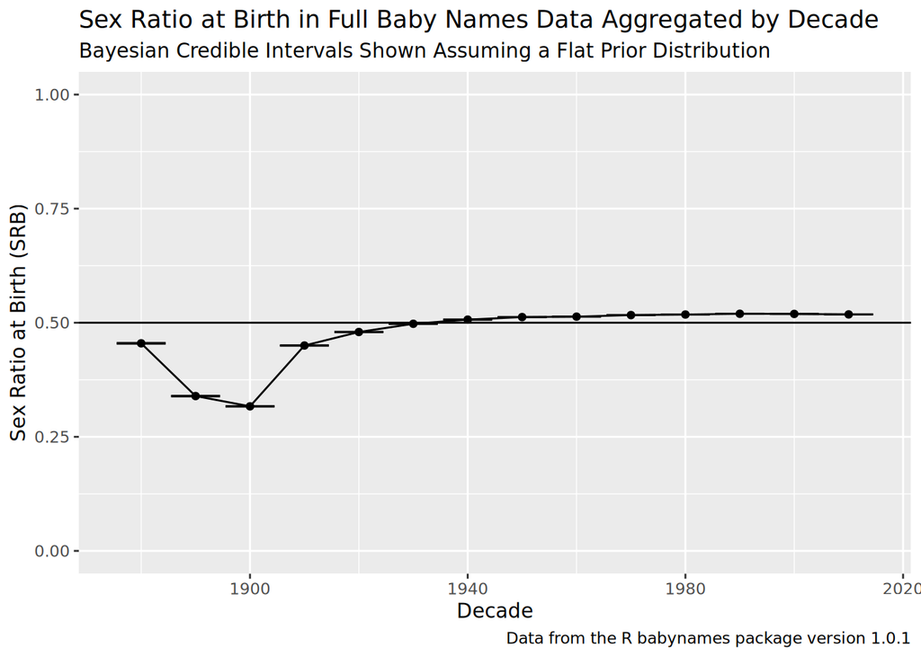

```r
as_tibble(babies_born_by_decade_and_sex_full) |>
  ggplot(aes(x = decade, y = sex_ratio)) +
  geom_errorbar(aes(ymin = lower, ymax = upper)) +
  geom_point() +
  geom_line() +
  ylim(0, 1) +
  geom_hline(yintercept = 0.5) +
  labs(x = "Decade", y = "Sex Ratio at Birth (SRB)", title = "Sex Ratio at Birth in Full Baby Names Data Aggregated by Decade", subtitle = "Bayesian Credible Intervals Shown Assuming a Flat Prior Distribution", caption = "Data from the R babynames package version 1.0.1")
```

32. Finish by adding a Quarto citation to the babynames package (the one that you previously added to the file `DSC-011-Sp25-Lab13.bib`) here, by writing the `@-sign` (`@`) followed by “wickham21” the record key that you previously used to name the bibliographic record for the babynames R package when you edited the file `DSC-011-Sp25-Lab13.bib`.

Data taken from Wickham (2021)

When you render, this reference should appear at the end of your notebook exported HTML.

33. Check that now.

##### 2.4.2.5 Multiplot the two Datasets to Make Results Easier to Compare

To multiplot the two datasets in the same graph, we need to row-bind the `babies_born_by_decade_and_sex` data-frame and the `babies_born_by_decade_and_sex_full` tibble together, and add a new column that identifies which dataset each row belongs to. Then we can associate the dataset with an aesthetic like color to identify the dataset of origin in the graph. In order to use tidyverse() `bind_rows()` to bind the tibble and data-frame by rows, we need to adapt the names and column order of columns of the `babies_born_by_decade_and_sex` data-frame to be the same as in the `babies_born_by_decade_and_sex_full` tibble. Please do this in the following steps.

```r
babies_born_both <- babies_born_by_decade_and_sex |>
  relocate(decade, .before="boy_freq") |>
  rename(M = boy_freq) |>
  rename(F = girl_freq) |>
  bind_rows(babies_born_by_decade_and_sex_full) |>
  mutate(dataset = rep(c("top200", "full"), each = 14))
try(digest::digest(babies_born_both |>
                 mutate(across(where(is_double),round,digits=7))) ==  "bff7b8f4add9f112373ab89e039d8411"
)
```

```
[1] TRUE
```

36. Now down in the R Console, pipe the `babies_born_both` data-frame into a graph expression that has the following characteristics, using a copy of your previous graph expression as a starting point:
1. Use `aes()` in the call to `ggplot()` to associate the aesthetics x with decade, y with sex_ratio, and color with dataset.
2. Use `geom_errorbar()` with an additional call to `aes()` to associate the aesthetic ymin with the name “lower” and ymax with the name “upper”.
3. Make the point estimates easier to see by extending the graph expression with calls to `geom_point()` and `geom_line()`
4. Extend the graph expression with `ylim()` to set the y-axis limits to the values 0 and 1.
5. Extend the graph expression with `geom_hline(yintercept=0.5)` to draw a reference line for an even sex ratio of 0.5.
6. Extend the graph expression to add meaningful labels of “Decade” for the x-axis, “Sex Ratio at Birth (SRB)” for the y-axis, “Sex Ratio at Birth By Decade in Top200 and Full Baby Names Datasets” as a title, “Bayesian Credible Intervals Shown Assuming a Flat Prior Distribution” as a subtitle, and `"Data from U.S. SSA and R babynames package 1.0.1"` as the caption.
7. Make the plot colorblind-friendly using the `ggokabeito` package.
37. After you have perfected your graph expression in the Console, please copy it here to include the graph in your notebook:

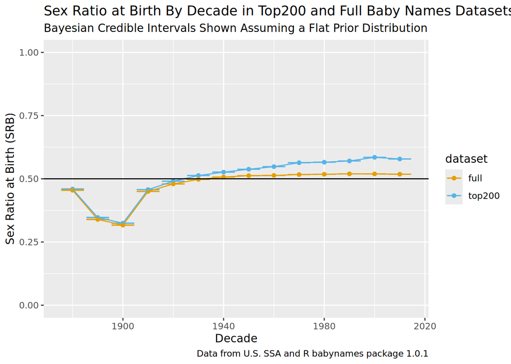

```r
babies_born_both |>
  ggplot(aes(x = decade, y = sex_ratio, color = dataset)) +
  geom_errorbar(aes(ymin = lower, ymax = upper)) +
  geom_point() +
  geom_line() +
  ylim(0, 1) +
  geom_hline(yintercept=0.5) +
  scale_color_okabe_ito(aesthetics = "color") +
  labs(x = "Decade", y = "Sex Ratio at Birth (SRB)", title = "Sex Ratio at Birth By Decade in Top200 and Full Baby Names Datasets", subtitle = "Bayesian Credible Intervals Shown Assuming a Flat Prior Distribution", caption = "Data from U.S. SSA and R babynames package 1.0.1")
```

#### 2.4.3 Your Interpretation

38. Use this space below to write short original answers to the following questions:

##### 2.4.3.1 How Consistent is the Data with the Hypothesis of an Even SRB of 0.5?

##### 2.4.3.2 Why Does the Full Dataset Level Out More Towards a Constant Male-Biased SRB than the Top200 dataset?

##### 2.4.3.3 What Factors Do You Think Might Contribute to Making the SRB in Early Decades So Different From Later Decades?

### 2.5 Popularity over Decades: Aggregating Rank Statistics Over Decades: Top-200 Baby Names Data

Let’s regenerate the Lollipop Chart of mean ranks of names over decades.

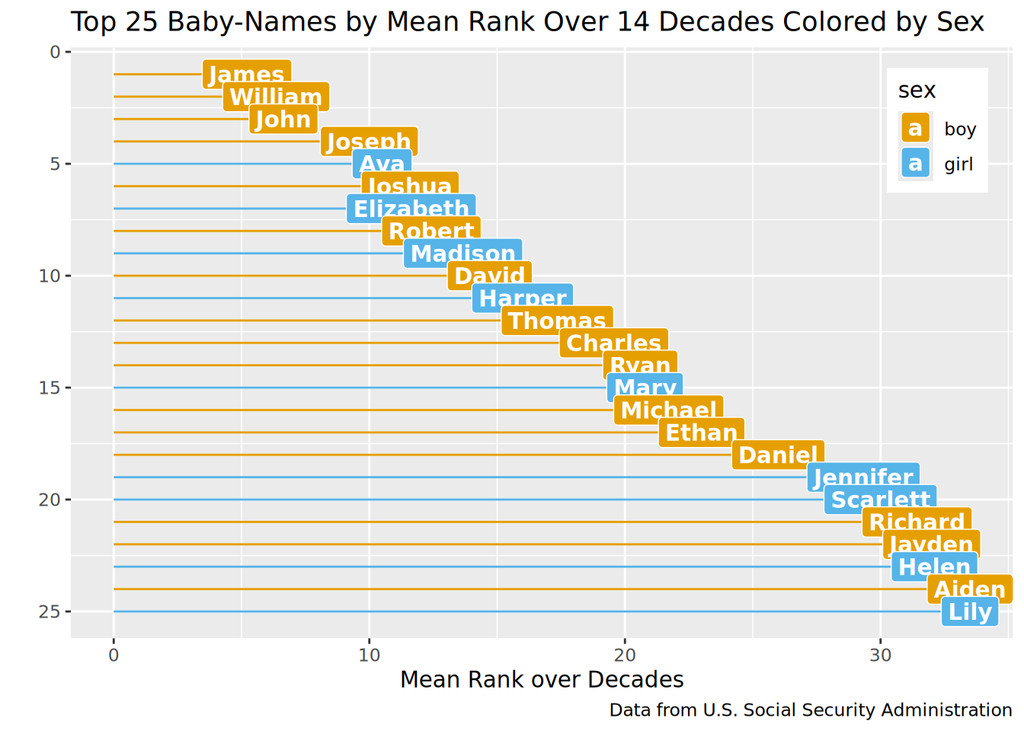

```r
names_by_mean_rank <- mean_rank_by_name_and_sex[order(mean_rank_by_name_and_sex$mean_rank),]
names_by_mean_rank$rank <- 1:1236
as_tibble(names_by_mean_rank) |>
    slice(1:25) |>
    ggplot(aes(y=rank,x=mean_rank,color=sex,label=name)) +
      geom_segment(aes(y = rank, yend = rank, x = 0, xend = mean_rank)) +
      geom_label(aes(fill=sex),
                 color="white",
                 fontface = "bold")  +
      scale_y_reverse() +
      scale_color_okabe_ito() +
      scale_fill_okabe_ito() +
      labs(x="Mean Rank over Decades",
           y="",
           title="Top 25 Baby-Names by Mean Rank Over 14 Decades Colored by Sex",
           caption="Data from U.S. Social Security Administration") +
      guides(color = guide_legend(position = "inside")) +
      theme(legend.position.inside = c(0.92, 0.86))
```

This is a very crude method to aggregate rank data over decades, because it fails to take **uncertainty** into account. That is, the amount of data that we have for each name varies. Some names might have been popular in only one decade or a few decades, while other names could have been popular in all 14 decades. In computing the mean ranks or overall ppopularity of names over decades, we want to take the sample sizes, that is, the number of decades names in which decades are ranked, into account. One way to do this is to visualize confidence intervals for the mean ranks.

#### 2.5.1 Calculating Confidence Intervals for Mean Ranks of Names Over Decades

We can use the base-R function called `t.test()` to compute confidence or credible intervals for both sample means and for differences in two sample means, whether they are paired or independent.

39. To get a feel for using the `t.test()` function for a one-sample confidence interval for a sample mean, run the following code chunk:

```r
t.test(c(1,15,24),conf.level = 0.99)
```

```
    One Sample t-test

data:  c(1, 15, 24)
t = 1.9925, df = 2, p-value = 0.1845
alternative hypothesis: true mean is not equal to 0
99 percent confidence interval:
 -53.07995  79.74661
sample estimates:
mean of x
 13.33333
```

40. Now experiment to extract information from the return value of `t.test()` (which is a list) by chaining the name selection operator ($) to the right side of the function call, and adding the name `conf.int`. Please edit this following code chunk accordingly to extract only the confidence interval from the return value of t.test() in a single R expression with no assignments.

```r
t.test(c(1,15,24),conf.level = 0.99)$conf.int
```

```
[1] -53.07995  79.74661
attr(,"conf.level")
[1] 0.99
```

41. Finally, experiment further by appending the vector selection operator ([ ]) to the expression in the previous code chunk. Use the index 1 to extract only the lower bound of the confidence interval from the return value of `t.test()` in a single R expression with no assignments:

```r
t.test(c(1,15,24),conf.level = 0.99)$conf.int[1]
```

```
[1] -53.07995
```

The fastest way to compute interval estimates for mean ranks in the top200 data would be to go back and modify the base-R code that computes the `mean_rank_by_name_and_sex` data-frame, but this base-R code is too complicated to read and to edit, especially given the complications of modifying it to use calls to `t.test()`.

Let’s start by regenerating this data summary using a tidyverse pipeline instead. It’s remarkably simple and readable, and shows off the advantages of the tidyverse.

```r
baby_clean_tidy |> group_by(name,sex) |> summarize(mean_rank=mean(rank))
```

```
# A tibble: 1,236 × 3
# Groups:   name [1,209]
   name    sex   mean_rank
   <chr>   <chr>     <dbl>
 1 Aaliyah girl       68
 2 Aaron   boy       103.
 3 Abbie   girl      197
 4 Abby    girl      194
 5 Abel    boy       177
 6 Abigail girl       50.8
 7 Abraham boy       176.
 8 Ada     girl       91.6
 9 Adalyn  girl      169
10 Adalynn girl      154
# ℹ 1,226 more rows
```

```r
baby_clean_tidy |>
  group_by(name,sex) |>
  summarize(mean_rank=mean(rank))
```

```
# A tibble: 1,236 × 3
# Groups:   name [1,209]
   name    sex   mean_rank
   <chr>   <chr>     <dbl>
 1 Aaliyah girl       68
 2 Aaron   boy       103.
 3 Abbie   girl      197
 4 Abby    girl      194
 5 Abel    boy       177
 6 Abigail girl       50.8
 7 Abraham boy       176.
 8 Ada     girl       91.6
 9 Adalyn  girl      169
10 Adalynn girl      154
# ℹ 1,226 more rows
```

```r
try(digest::digest(summary(names_by_mean_rank_conf)) == "86deb2e02e0bffdcab5bdc053cb91f46")
```

[output not shown]

#### 2.5.2 Examining Credible Intervals for the Top 25 Names

44. Inspect your results for the top 25 names by executing the following code chunk. Use the navigator links at the bottom of the Source Pane in RStudio to tab through all three pages of rows.

```r
try(as_tibble(names_by_mean_rank_conf) |>
    slice(1:25) |> print(n=Inf))
```

[output not shown]

#### 2.5.3 Better Rank Aggregation of Baby Names Data over Decades

In a study on Rank Aggregation methods, Li, Wang, and Xiao (2017) found that the generally best performing algorithm and implementation over a range of scenarios studied was the Borda count method using an aggregation function over the geometric mean of ranks as implemented in the R package `TopKLists` (Schimek et al. 2015). In their analysis they particularly examined the case of a Top-K only list such as in our top-200 Baby names data.

The Borda count method is an extremely old method. You can read more about it at the [Borda count wikipedia page](https://en.wikipedia.org/wiki/Borda_count).

in order to use `TopKLists::Borda()` we need to make a list of vectors of boys or girls names for each decade and sex in the data. One easy way to make new lists from data-frames, conditioned on a factor, is through the `split()` function as we previously saw in Lab 10.

45. Follow these steps in the RConsole to aggregate ranks over decades for the boys and girls names, while seeing how the data is transformed step-by-step:
1. Call `split()` on `baby_clean` as first argument and `baby_clean_f$decade` as second argument and save it to a list called `sp`.
2. Create a list of vectors of boys names for each decade in rank order with the code `do.call(list,lapply(sp,function(x)x$boy_name))` and save it to a list named `boys`
3. Create a list of vectors of girls names for each decade in rank order with the code `do.call(list,lapply(sp,function(x)x$girl_name))` and save it to a list named `girls`
4. Combine the two lists into one with the function `boys_girls = c(boys,girls)`
5. Validate your work with the call `str(boys_girls)`.
6. Call `Borda(boys_girls)`
7. Save the return value to the variable `Borda_top200`.
46. Save your validated code for defining `Borda_top200` in the code chunk below to test the value:

```r
try(digest::digest(Borda_top200$Scores |>
                 mutate(across(where(is_double),round,digits=7)))  ==
  "a298d2fea5f44e5f1a0ddf1d6baeb8b7"
)
```

[output not shown]

Although this method does not give us confidence intervals, it does correctly handle the fact that not all names are present in every decade, which leads to different sample sizes for different names, and even correctly handles the largely disjoint sets of boys and girls names in the data.

47. Modify the following code chunk to use the `head()` and `tail()` functions to examine the top 50 and bottom 50 names for the `geo.mean` column of the `TopK` data-frame of `Borda_top200`. To do this correctly, you need to provide two selections on `Borda_top200` and supply a value 50 to the `n` optional arguments to `head()` and `tail()`:

```r
cat("# Top 50 Names Over 14 Decades by Borda Count on Top 200 Dataset\n")
```

```
# Top 50 Names Over 14 Decades by Borda Count on Top 200 Dataset
```

```r
try(head(Borda_top200))
```

[output not shown]

```r
cat("\n# Bottom 50 Names Over 14 Decades by Borda Count on Top 200 Dataset\n")
```

```
# Bottom 50 Names Over 14 Decades by Borda Count on Top 200 Dataset
```

```r
try(tail(Borda_top200))
```

[output not shown]

48. Please think about and answer here: Do you think these results with Borda count are better or worse summaries of name popularity over decades than the results with mean rank? Please briefly explain your answer.

## 3 References

Holmes, Susan, and Wolfgang Huber. 2019. *Modern Statistics for Modern Biology*. Cambridge, United Kingdom: Cambridge university press.

Johnson, Alicia A., Miles Q. Ott, and Mine Dogucu. 2022. *Bayes Rules! An Introduction to Bayesian Modeling*. First edition. Chapman & Hall/CRC Texts in Statistical Science. Boca Raton London New York: CRC Press.

Li, Xue, Xinlei Wang, and Guanghua Xiao. 2017. “A Comparative Study of Rank Aggregation Methods for Partial and Top Ranked Lists in Genomic Applications.” *Briefings in Bioinformatics* 20 (1): 178–89. https://doi.org/10.1093/bib/bbx101.

Moore, Cristopher., and Stephan. Mertens. 2011. *The Nature of Computation*. Oxford: Oxford University Press.

Schimek, Michael G., Eva Budinská, Karl G. Kugler, Vendula Švendová, Jie Ding, and Shili Lin. 2015. “TopKLists: A Comprehensive R Package for Statistical Inference, Stochastic Aggregation, and Visualization of Multiple Omics Ranked Lists.” *Statistical Applications in Genetics and Molecular Biology* 14 (3): 311–16. https://doi.org/10.1515/sagmb-2014-0093.

Wickham, Hadley. 2021. *Babynames: US Baby Names 1880-2017*. https://CRAN.R-project.org/package=babynames.